# Análise da Replicação One-vs-Rest

Davvi Duarte Rodrigues

# 1. Leitura dos artefatos

# 2. Tabela principal de desempenho

Desempenho médio do KNN em configuração one-vs-rest.

| Cenário | Melhor K | Acurácia média | F1 médio | FAR média | FRR média |
| --- | --- | --- | --- | --- | --- |
| Atributos da replicação | 1 | 98,6% | 92,9% | 0,8% | 7,0% |
| Atributos do artigo original | 3 | 96,9% | 81,3% | 1,7% | 16,0% |

# 3. Gráfico principal: F1-score médio por K

Este é o gráfico mais importante para o artigo, pois compara diretamente o desempenho dos atributos selecionados pela replicação contra os atributos finais do artigo original.

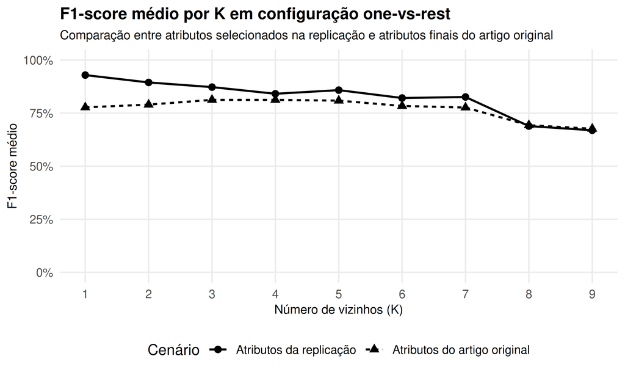

**Legenda sugerida para o artigo:** F1-score médio do KNN em configuração one-vs-rest para diferentes valores de K.

# 4. Gráfico de acurácia média por K

Este gráfico é complementar. Ele mostra que ambos os cenários possuem alta acurácia, mas deve ser interpretado junto com o F1-score, FAR e FRR por causa do desbalanceamento do one-vs-rest.

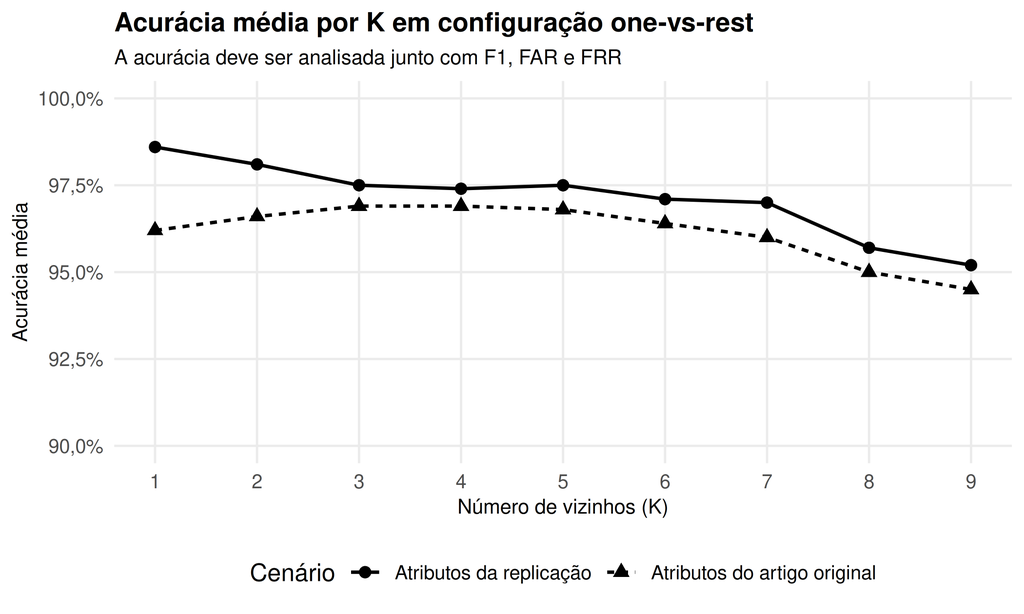

**Legenda sugerida para o artigo:** Acurácia média do KNN em configuração one-vs-rest para diferentes valores de K.

# 5. Gráfico de FAR e FRR no melhor K

Este gráfico é recomendado para discutir autenticação, pois mostra os erros mais importantes: aceitar indevidamente outro usuário e rejeitar o usuário autêntico.

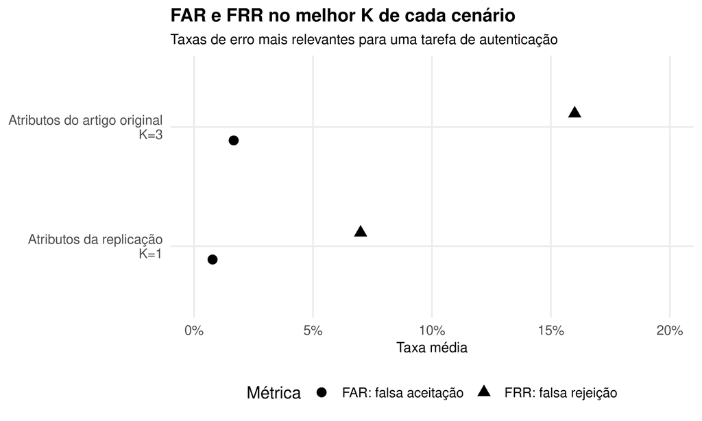

**Legenda sugerida para o artigo:** Taxas médias de falsa aceitação e falsa rejeição nos melhores valores de K de cada cenário.

# 6. Sobreposição entre atributos do artigo e da replicação

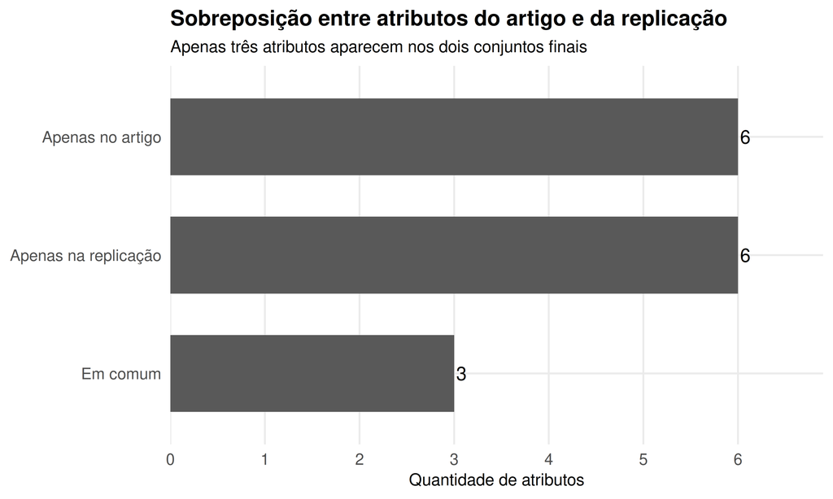

**Legenda sugerida para o artigo:** Sobreposição entre os atributos finais do artigo original e os atributos selecionados nesta replicação.

# 7. Motivos de exclusão dos atributos

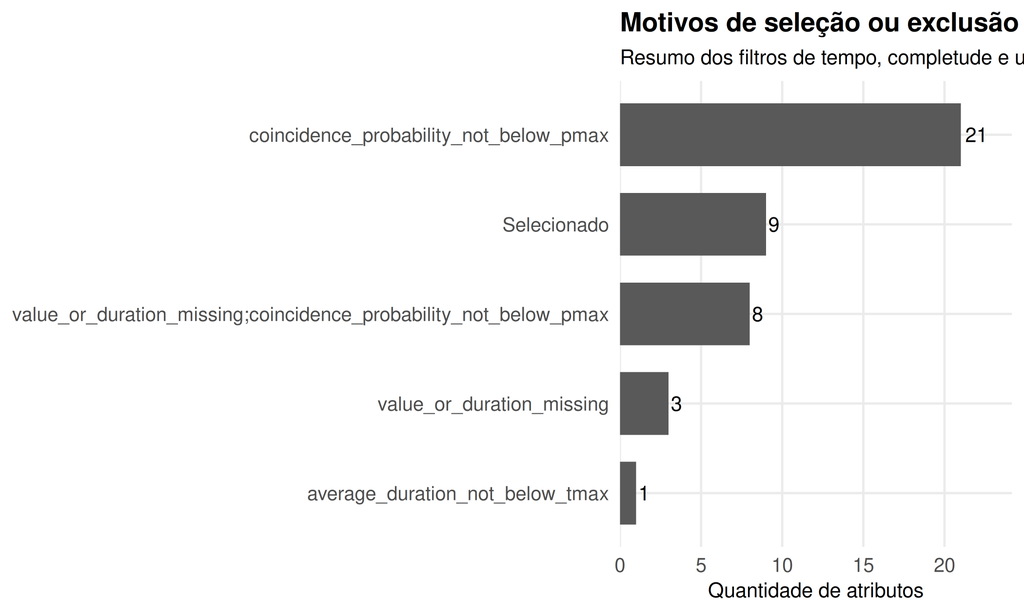

**Legenda sugerida para o artigo:** Distribuição dos motivos de seleção ou exclusão dos atributos após a aplicação dos filtros metodológicos.

# 8. Desempenho por participante no melhor K

Este gráfico é opcional. Ele pode ser usado no relatório complementar ou em apêndice, pois mostra quais participantes foram mais fáceis ou difíceis de autenticar.

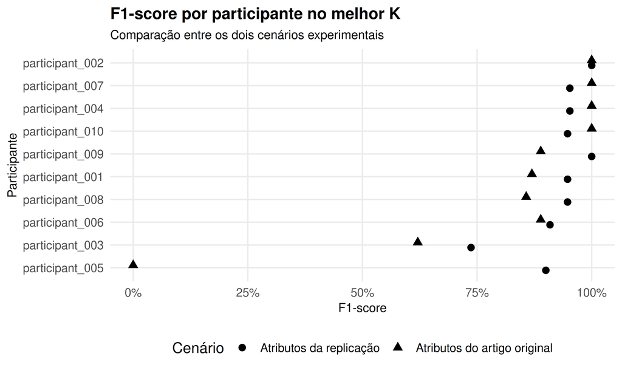

# 9. Arquivos gerados

Se `params$export_figures` estiver definido como `true`, os gráficos principais serão salvos em:

- `figures/fig_acuracia_por_k.png`
- `figures/fig_f1_por_participante.png`
- `figures/fig_f1_score_por_k.png`
- `figures/fig_far_frr_melhor_k.png`
- `figures/fig_motivos_exclusao.png`
- `figures/fig_sobreposicao_atributos.png`